# Summary report 2012

UKMON

27 Nov 2016

```
## [1] "Dataset: ALL period 2012-08-09 to 2012-12-15"
```

# Summary of activity

In 2012 a total of 4 cameras cntributed data to the UKMON repository. Together, these cameras recorded 1039 individual meteor observations. The number of recorded observations by station is as follows:

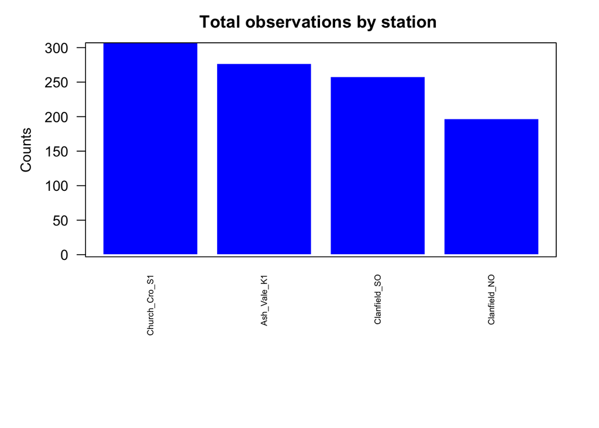

After applying quality criteria`we found that 346 meteors were observed by more than one camera (Unified observations). The following shows a count of the number of meters observed by two, three, etc. cameras.

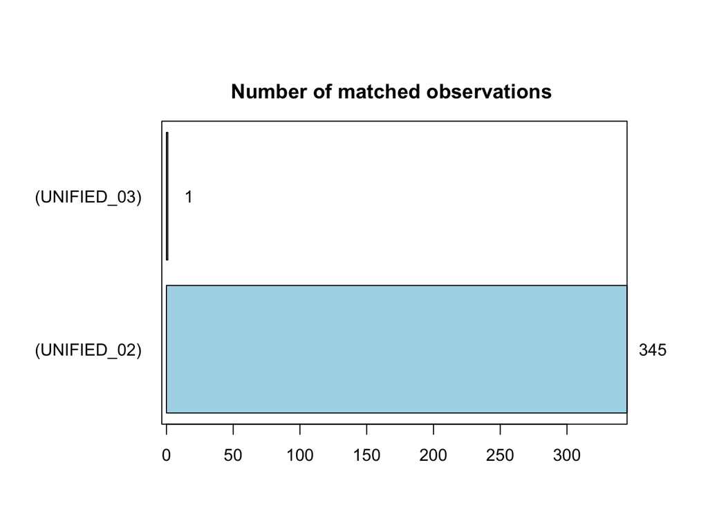

The number of unified observations as a percentage of individual observations is 33.3%. A breakdown of unified observation counts by stream (top ten) is as follows:

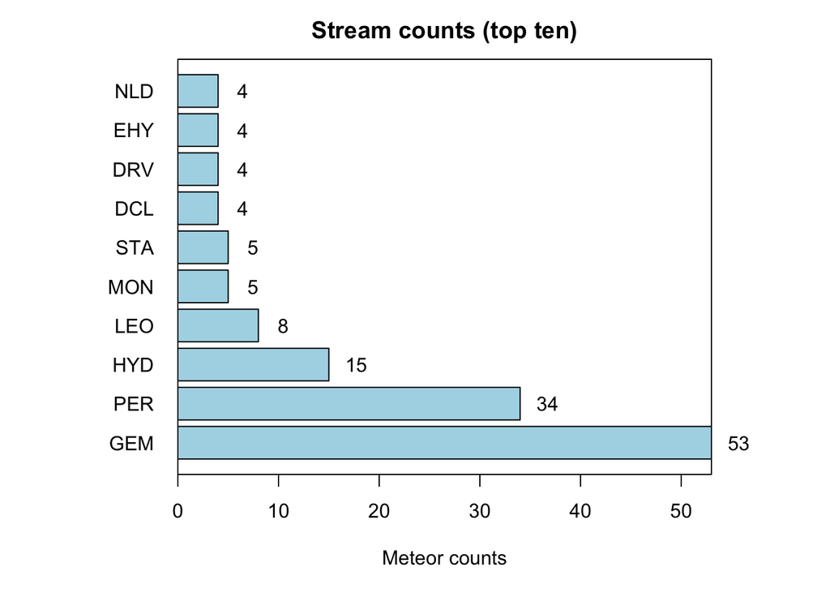

## Fireball activity

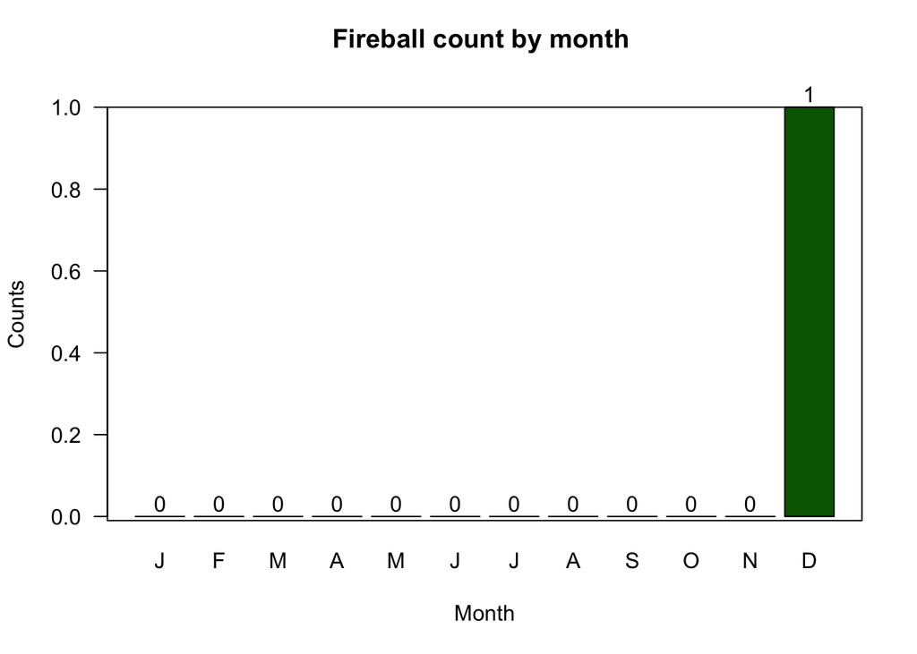

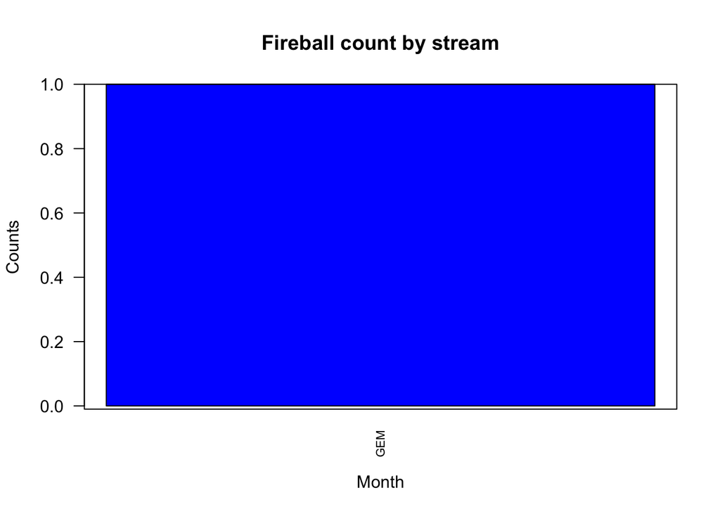

The brightest (top 10) fireballs observed during 2012 were:

| Datetime | Magnitude | Stream | Station matches |
| --- | --- | --- | --- |
| 2012-12-15 03:41:00 | -4.4 | GEM | 2 |

## Velocity distribution

The following graphs show the distribution of velocities:

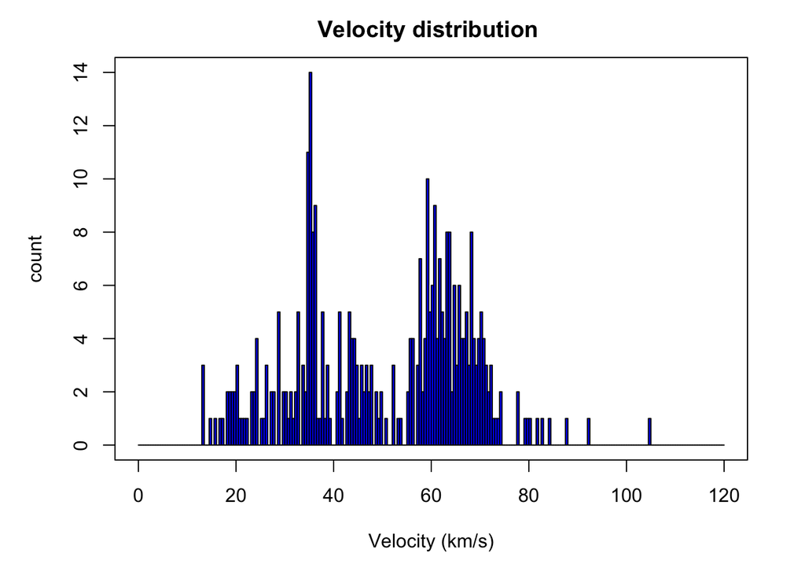

## Magnitudes

The following graphs show the distribution of magnitudes:

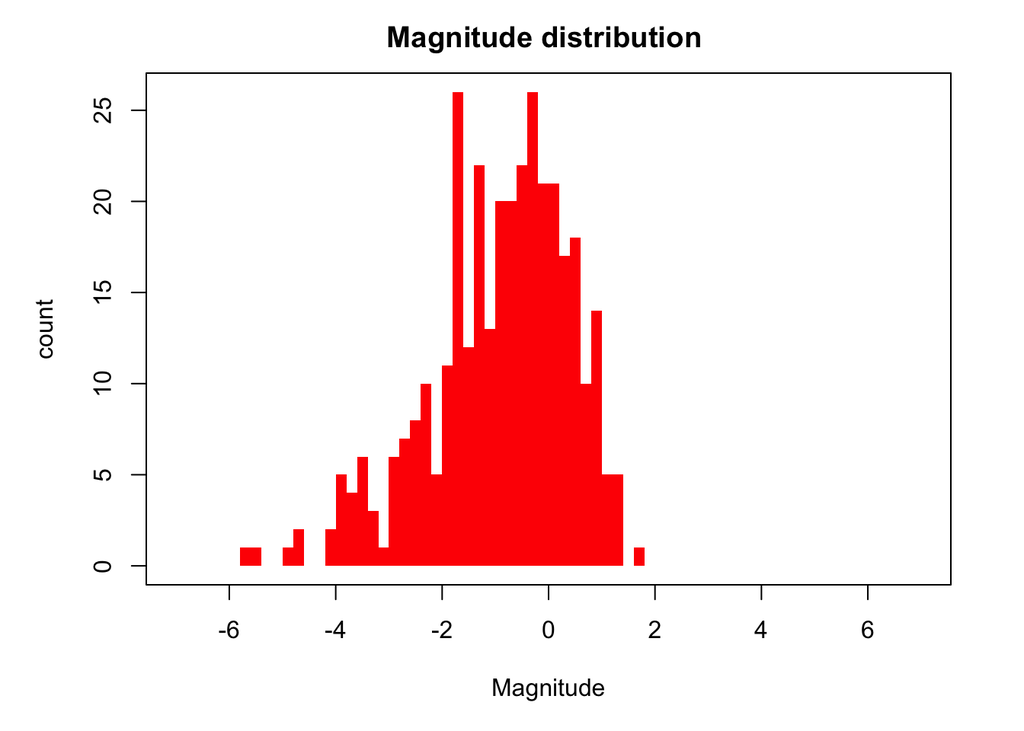

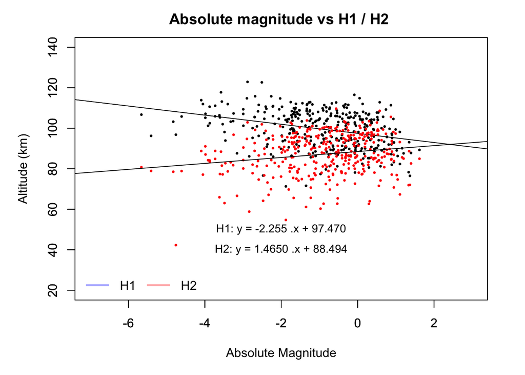

The following plots shows the altitude of the atart and end of ablation for each individual meteor. The plot is in order of decreasing start height and gives a good visualisation of the depth of the ablation zone. Where in the atmosphere ablation occurs will depend on factors such as meteor velocity and composition.

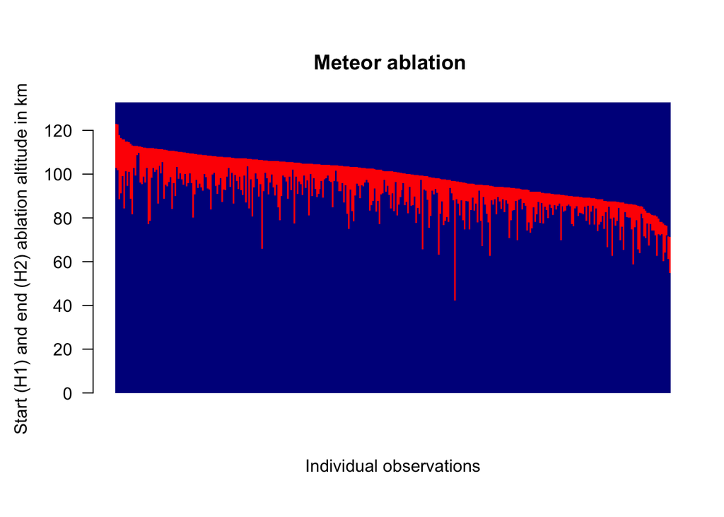

The maximum observed altitude was 122.9 km and the minimum observed altitude was 42.3 km. The distribution of distances travelled through the ablation zone was as follows:

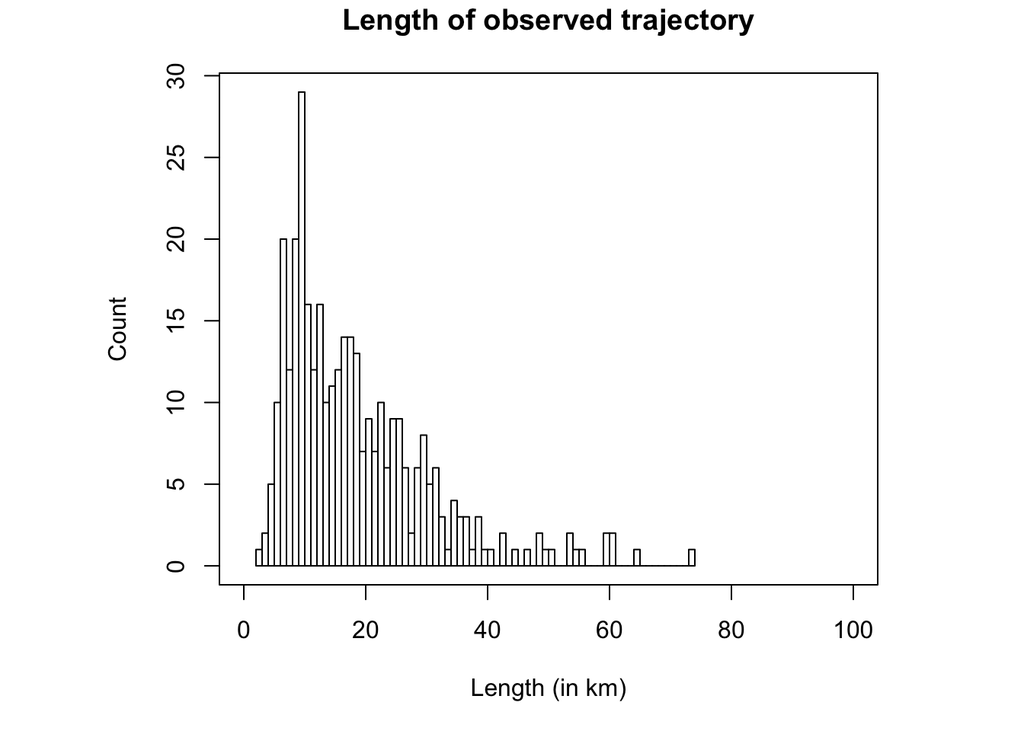

## Other Data of Interest

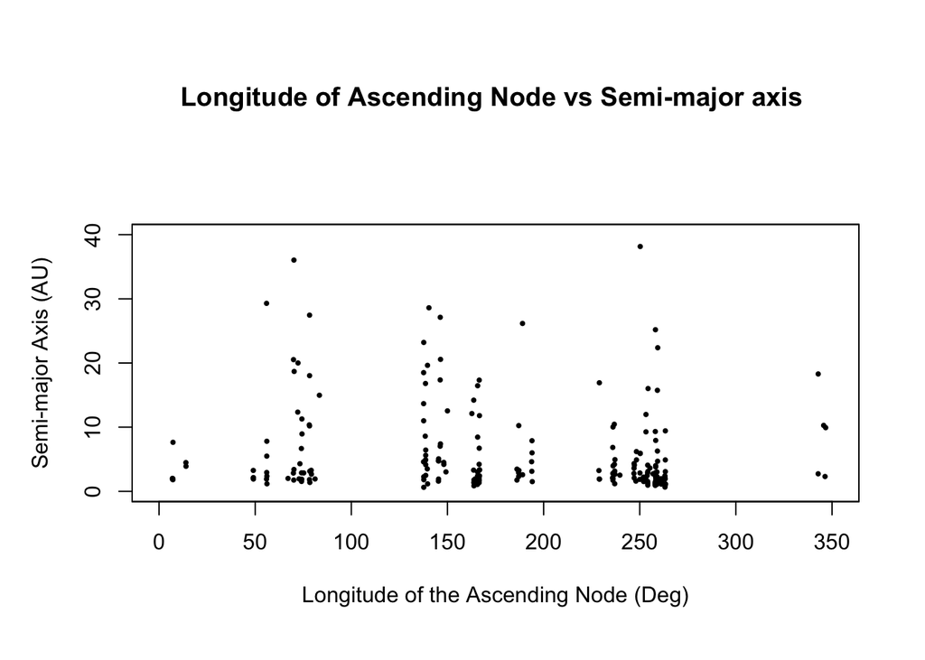

## Data matching

The following table shows the camera pairings that are producing the highest number of unified observations.

[output not shown]

[figure not shown]

## Data Quality Indicators

The following plot shows the average linearity error in the processing of data:

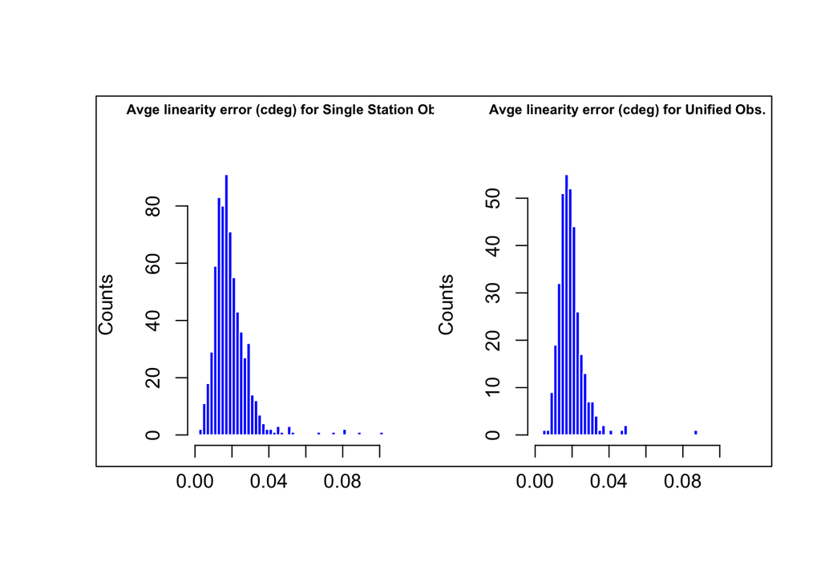

The following graph shows the distribution of differences in velocity between matched observations:

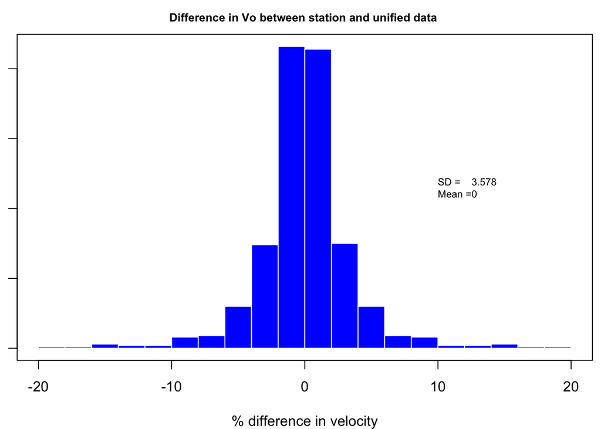